# PISA Scores Project

Sam Eckhardt, Joey Miranda

Tuesday, December 09, 2014

# Mission

The mission of these visualizations is to see if there is a way for the United States to improve its education system. In the last 50 years, several countries have passed the United States in overall education success, with the U.S. falling to 14th in the most recent ranking. We will look at a few of the countries above the United States, using the Programme for International Student Assessment (PISA), compiled the by Organisation for Economic Co-operation and Development (OECD). This data had over 400,000 observations of several hundred variables.

The dataset is quite large, so if you copy the following url into your browser, the download will start. Then save it into the folder in which you saved this .rmd file if you would like to edit.

http://beta.icm.edu.pl/PISAcontest/data/student2012.rda

```r
suppressPackageStartupMessages(library(googleVis))
library(ggplot2)
library(gridExtra)
library(gtable)
library(ggmap)
library(rCharts)
library(reshape2)
library(scales)
library(dplyr)
load("student2012.rda")
```

# Countries in Data

This is a visualization of all of the countries that the OECD did their survey in. They included countries from all over the world.

```r
Country <- gvisGeoChart(student2012, "CNT", "", options = list(region = "world",
    displayMode = "auto", resolution = "countries", width = 600,
    height = 400))
# plot(Country)
print(Country, file = "Country.html")
```

[interactive chart not shown]

# Countries Of Choice

This is a Google Visualization showing the countries that we chose to focus our report on. Our first idea was to look at the top countries in the world for education. We found that Japan, Singapore, Hong Kong, Finland, the United Kingdom, the Netherlands, Ireland, and Poland were all in the top 10, and were included in the PISA data. We decided that these were the countries we would compare to the United States. We end up with several European and Asian countries, as well as the United States.

```r
Select2012 = subset(student2012, CNT %in% c("Japan", "Singapore",
    "Hong Kong-China", "Finland", "United Kingdom", "Netherlands",
    "Ireland", "Poland", "United States of America"))

Countries <- gvisGeoChart(Select2012, "CNT", "", options = list(region = "world",
    displayMode = "auto", resolution = "countries", width = 600,
    height = 400))
# plot(Countries)
print(Countries, file = "Countries.html")
```

[interactive chart not shown]

# Question Selection

Our next step was to choose which questions we felt would be worth while to visualize. We decided to focus on questions that the United States government could improve with some sort of bill or change in the education system. This does not include some questions such as “How many televisions do you have at home?” Our thinking is that if we were to find that the main problem with education was something along those lines, then that would be a much more difficult fix for our education system to do. We thought we would look at some of the questions that we felt would be easy to improve with some simple legislation.

## Failure Levels

Our first thought was to look at failure levels. We thought we would compare the chosen countries to the united states, and count how many times their students had said they have repeated a grade. If there is a large and obvious difference between the United States and other nations in this regard, we have a basis for investigation.

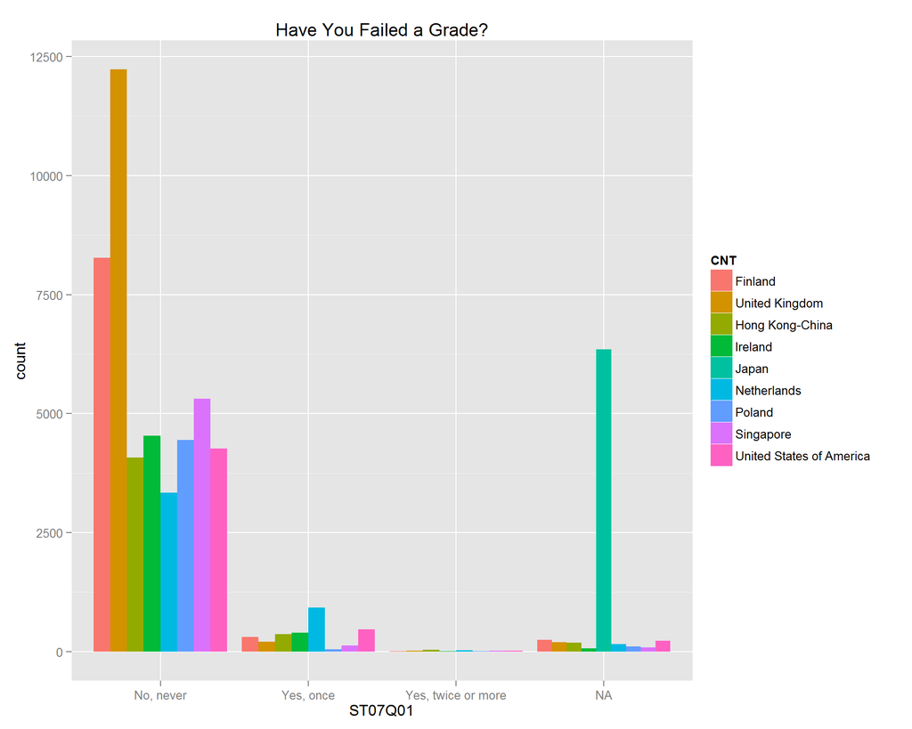

```r
# a=levels(student2012$CNT)


Questions2012 <- Select2012 %>% select(contains("CNT"), contains("ST04"),
    contains("ST07"), contains("ST29"), contains("ST43"), contains("ST44"),
    contains("ST46"), contains("ST49"), contains("ST55"), contains("ST57"),
    contains("ST69"), contains("ST70"), contains("ST71"))


ggplot(Questions2012, aes(x = ST07Q01, fill = CNT)) + geom_bar(position = "dodge") +
    ggtitle("Have You Failed a Grade?")
```

As you can see with the graph above, there are not very many people failing entire grades. We then looked at those that said they had failed, by filtering for only those that said “Yes, once”

```r
RepeatGradeCountry <- Questions2012 %>% filter(ST07Q01 == "Yes, once")

p1 <- rPlot(x = list(var = "CNT", sort = "count(ST07Q01)"), y = "count(ST07Q01)",
    data = RepeatGradeCountry, type = "bar", las = 2)
p1$guides(x = list(title = "Country"))
p1$guides(y = list(title = "Count"))
p1$addParams(title = "Failure Rate")
p1$save("chart1.html", cdn = TRUE)
```

[interactive chart not shown]

As we can see, the United States has 470 people polled that said they had to repeat a grade once. This is not necessarily an outrageous number, since all of the graphs are within a fairly similar range. Since the United States does not necessarily stand out in this particular case, our belief is that failure rates are not responsible for the difference between the United States and these other top 10 countries.

Since the survey continued on to evaluate each students opinions on multiple areas regarding schools subjects, we decided to look at the opinion of US students in comparison of the same top performing countries. A vast majority of the questiones sought after the students opinion on their education in mathmaticsfar beyond simple math and problem solving equations.

## Enjoyment

Our next idea was to look at some questions related to enjoyment. The majority of the study focuses on mathematics, so our thought was to look at mathematics more than science and reading. This first graph asks the question “Do you learn math because you enjoy it?”

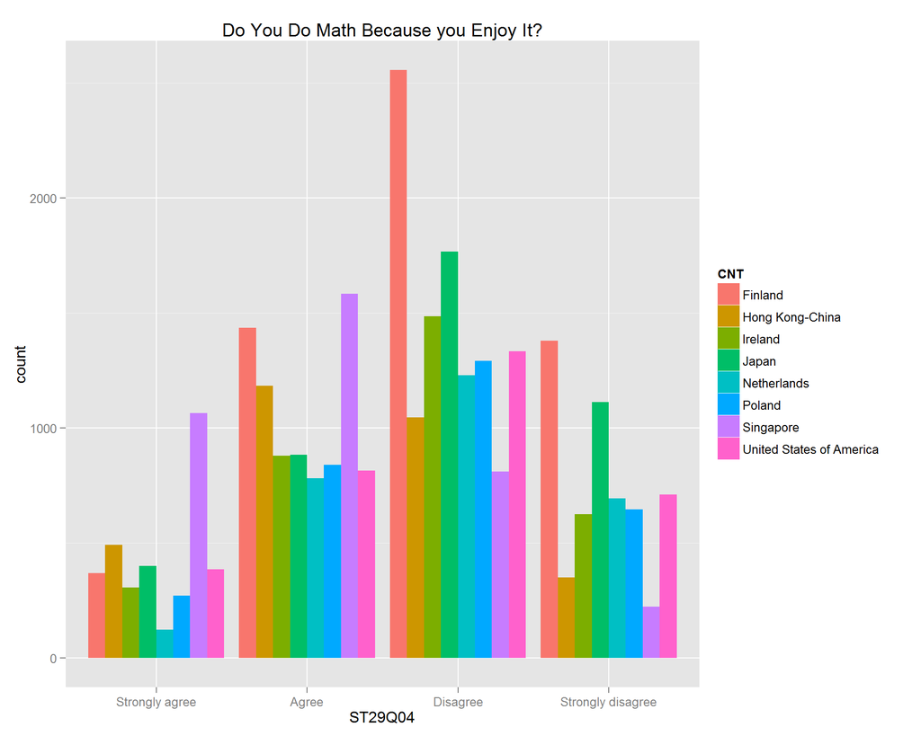

```r
MathEnjoy <- Questions2012 %>% filter(ST29Q04 != "NA") %>% filter(CNT !=
    "United Kingdom")

ggplot(MathEnjoy, aes(x = ST29Q04, fill = CNT)) + geom_bar(position = "dodge") +
    ggtitle("Do You Do Math Because you Enjoy It?")
```

The next question is “Do you believe math will improve your career?”

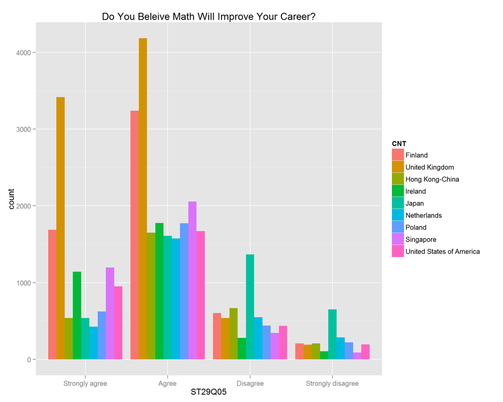

```r
MathCareer <- Questions2012 %>% filter(ST29Q05 != "NA")

ggplot(MathCareer, aes(x = ST29Q05, fill = CNT)) + geom_bar(position = "dodge") +
    ggtitle("Do You Beleive Math Will Improve Your Career?")
```

Along with the pack, the United States’ students believe that having a solid understainding of mathmatics will present them with a desirable career or improve a career they are already pursuing. Interestingly enough, Japan showed a trend with a fair amount of studuents saying the opposite.

The next question was “Do you expect to study math in the future?”

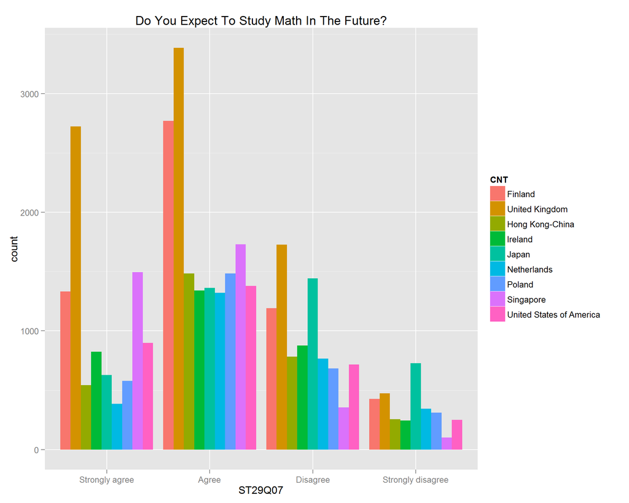

```r
MathStudy <- Questions2012 %>% filter(ST29Q07 != "NA")

ggplot(MathStudy, aes(x = ST29Q07, fill = CNT)) + geom_bar(position = "dodge") +
    ggtitle("Do You Expect To Study Math In The Future?")
```

This showed that many students expect to have to use math in the future. Showing that students are well aware math plays a pivotal role in their education, and that awareness is reciprocated in the United States as well.

These three graphs show that while many American students do not enjoy math, they still expect to study and use it in the future. The enjoyment level does not change that fact. As well, the United States compares similarly to the rest of the selected countries in this regard. Enjoyment, therefore, is not a reason for the U.S. falling behind in this regard.

## Effort

Our next thought is perhaps U.S. students lack in how much effort put to into their math studies. The next graph answers the question “If you put in enough effort, can you succeed in math?”

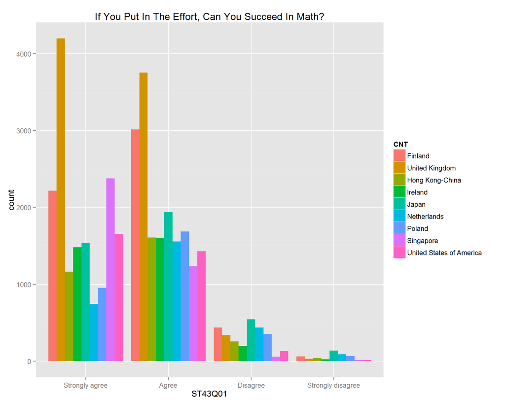

```r
MathEffort <- Questions2012 %>% filter(ST43Q01 != "NA")

ggplot(MathEffort, aes(x = ST43Q01, fill = CNT)) + geom_bar(position = "dodge") +
    ggtitle("If You Put In The Effort, Can You Succeed In Math?")
```

Across the board, each of these countries’ students believe that they can put enough effort to succeed into math, with very few disagreeing. The United States is in that pack as well. Since many students believe that if they can put in the effort, then they can succeed in math, it could be possible the demands of other possible obligations may be too high for the students to put in the optimal amount of effort in mathmatics specifically.

This next graph shows whether the demands of other time constraints are too conflicting for students to perform at their best in math.

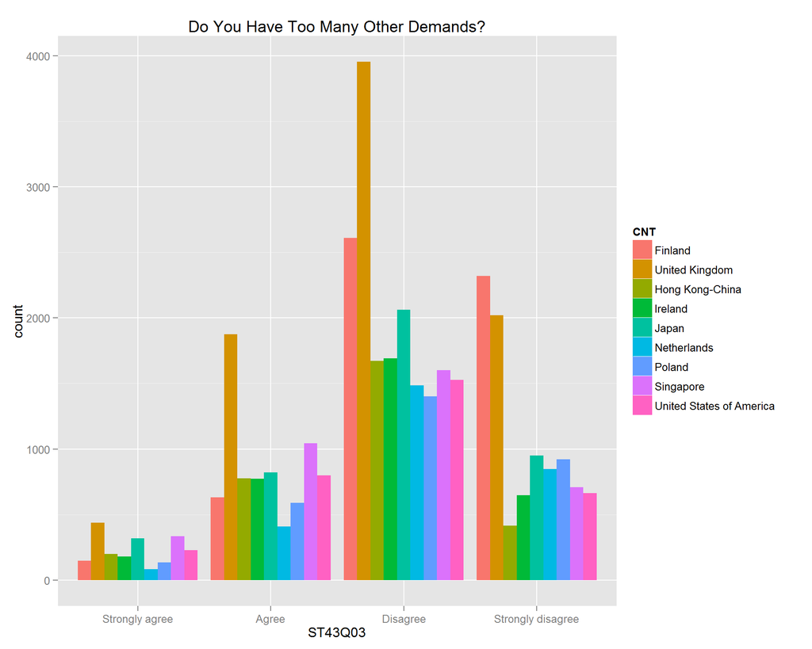

```r
MathDemands <- Questions2012 %>% filter(ST43Q03 != "NA")

ggplot(MathDemands, aes(x = ST43Q03, fill = CNT)) + geom_bar(position = "dodge") +
    ggtitle("Do You Have Too Many Other Demands?")
```

Most of the students polled say that other subjects are not too demanding, and the U.S. is right in the pack with the top 10 nations.

Another factor we looked at was whether math is too difficult. The next question is a competency question about their ability to solve mathematics problems. The answers range from likely to get a question wrong due to incompetency, to not likely to get a question wrong due to incompetency.

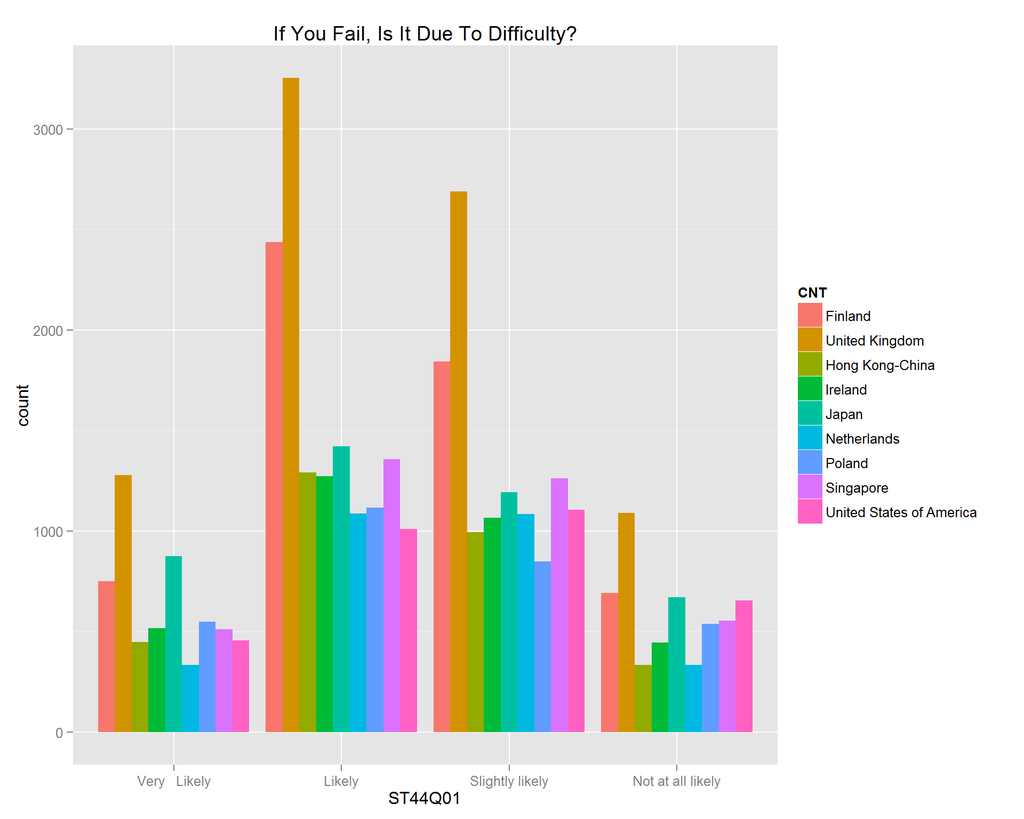

```r
MathDifficulty <- Questions2012 %>% filter(ST44Q01 != "NA")
ggplot(MathDifficulty, aes(x = ST44Q01, fill = CNT)) + geom_bar(position = "dodge") +
    ggtitle("If You Fail, Is It Due To Difficulty?")
```

## Preparation

Preparation is a major factor to success in any subject. If one is prepared for a test, one is much more likely to do well, especially in a subject such as math. This could likely be a place where the United States falls behind. The first question is “Do you get your homework done before class time on a usual basis?”

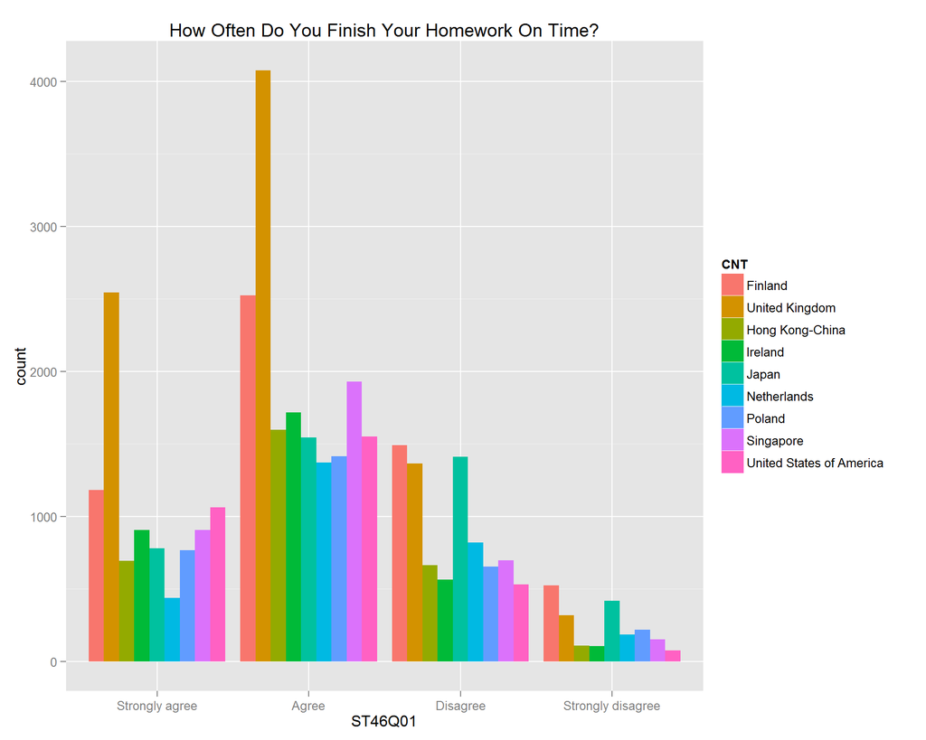

```r
MathHWK <- Questions2012 %>% filter(ST46Q01 != "NA")
ggplot(MathHWK, aes(x = ST46Q01, fill = CNT)) + geom_bar(position = "dodge") +
    ggtitle("How Often Do You Finish Your Homework On Time?")
```

As far as homework goes, the United States, for the most part does exactly what the rest of the top 10 does: gets their homework done on time.

The next question is about study preparation: Do you study enough for exams?

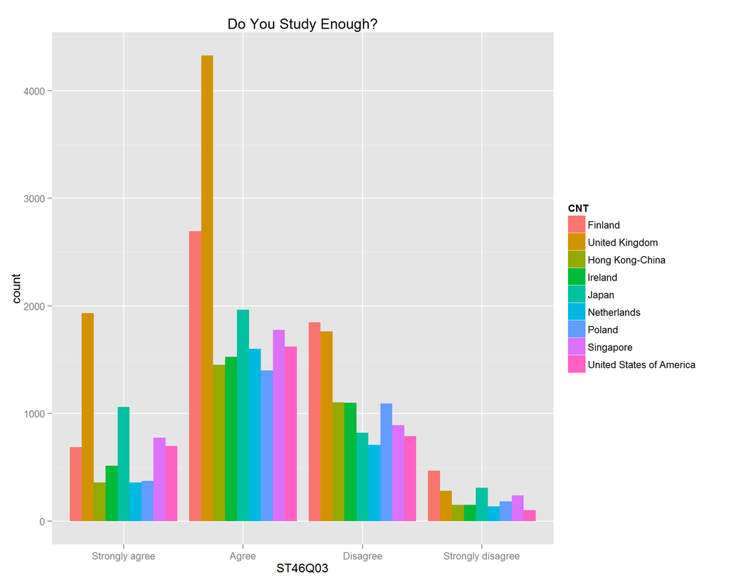

```r
MathPrep <- Questions2012 %>% filter(ST46Q03 != "NA")
ggplot(MathPrep, aes(x = ST46Q03, fill = CNT)) + geom_bar(position = "dodge") +
    ggtitle("Do You Study Enough?")
```

The United States says that for the most part they are, similarly they are right there with the rest of the top 10.

The next question is “Do you keep studying until you understand the material?”

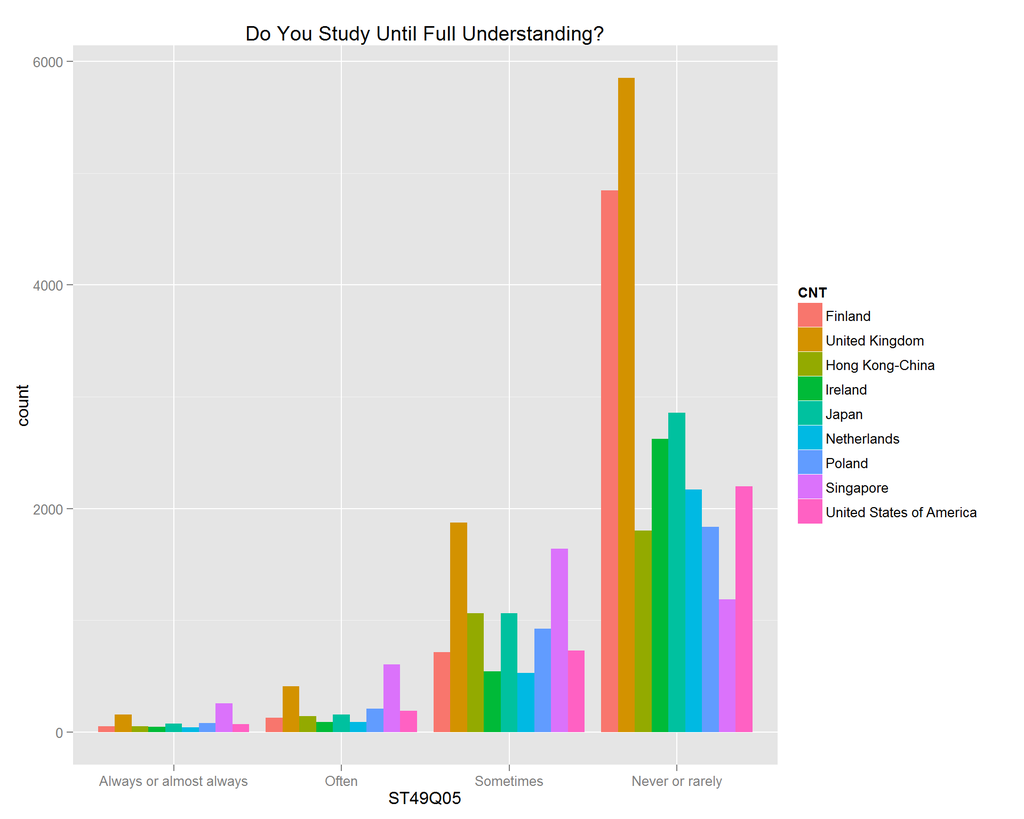

```r
MathHours <- Questions2012 %>% filter(ST49Q05 != "NA")
ggplot(MathHours, aes(x = ST49Q05, fill = CNT)) + geom_bar(position = "dodge") +
    ggtitle("Do You Study Until Full Understanding?")
```

Once again, the United States is still right in the mix of things in this case as well. So far, there is no really large difference between how the United States behaves on education compared to the rest of the world.

## Hours

The next thing we decided to look at is to see how many hours of lessons students take outside of normal school time. We decided to look at all subjects in these graphs.

The first subject we look at is math.

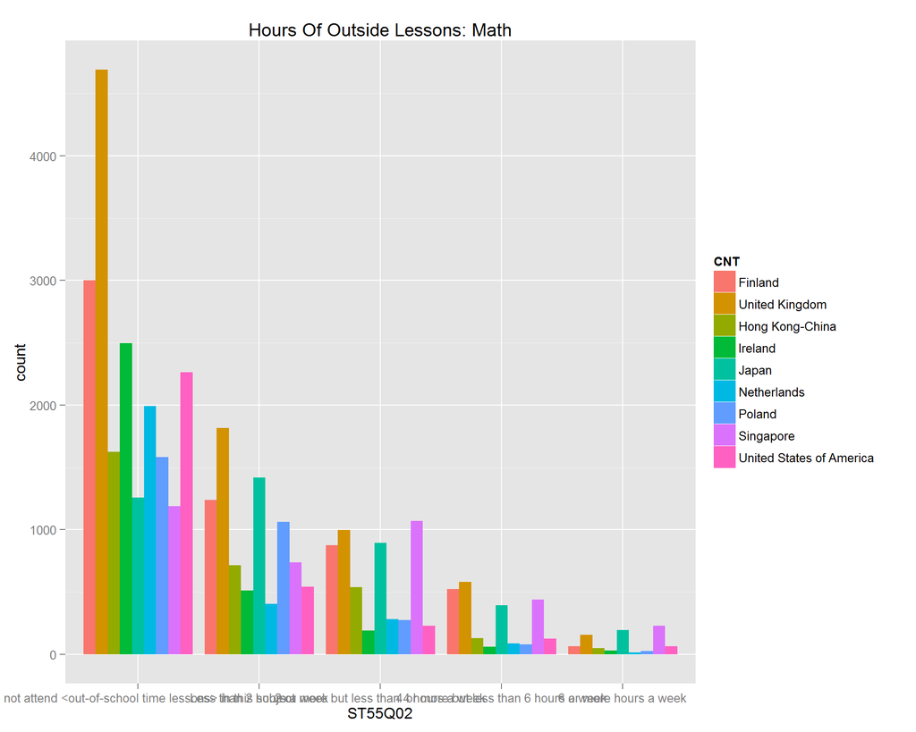

```r
SubjectHoursMath <- Questions2012 %>% filter(ST55Q02 != "NA")
ggplot(SubjectHoursMath, aes(x = ST55Q02, fill = CNT)) + geom_bar(position = "dodge") +
    ggtitle("Hours Of Outside Lessons: Math")
```

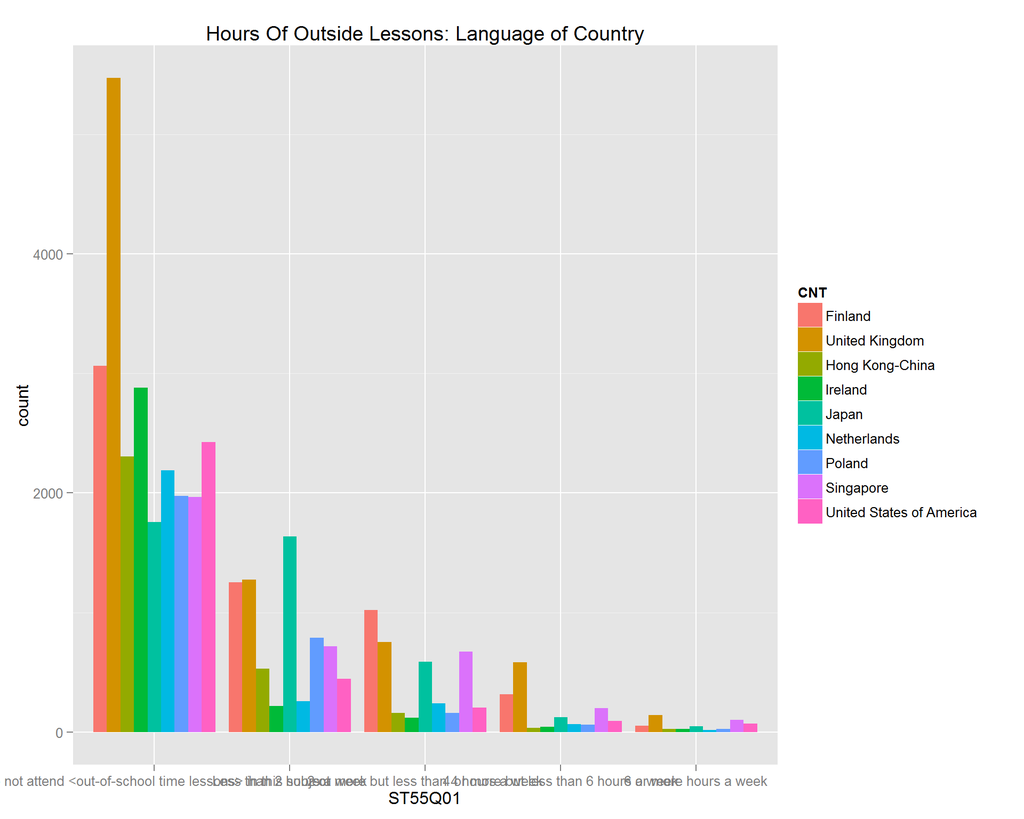

```r
SubjectHoursLanguage <- Questions2012 %>% filter(ST55Q01 != "NA")
ggplot(SubjectHoursLanguage, aes(x = ST55Q01, fill = CNT)) +
    geom_bar(position = "dodge") + ggtitle("Hours Of Outside Lessons: Language of Country")
```

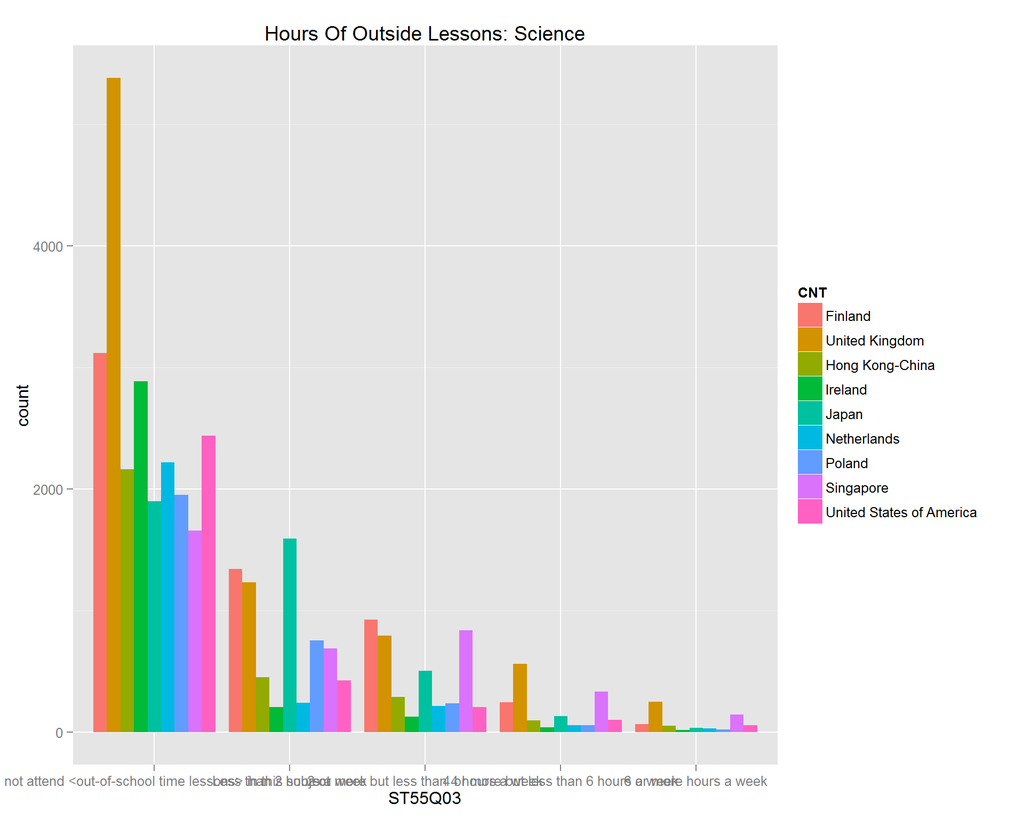

```r
SubjectHoursScience <- Questions2012 %>% filter(ST55Q03 != "NA")
ggplot(SubjectHoursScience, aes(x = ST55Q03, fill = CNT)) + geom_bar(position = "dodge") +
    ggtitle("Hours Of Outside Lessons: Science")
```

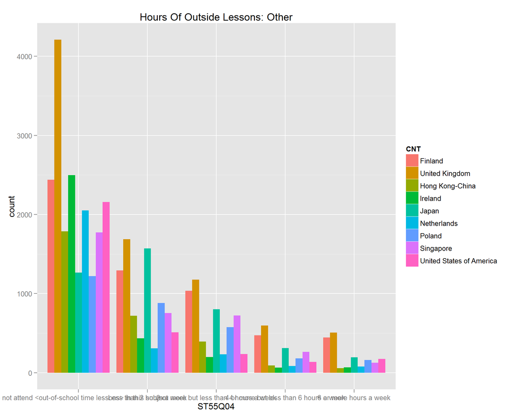

```r
SubjectHours <- Questions2012 %>% filter(ST55Q04 != "NA")
ggplot(SubjectHours, aes(x = ST55Q04, fill = CNT)) + geom_bar(position = "dodge") +
    ggtitle("Hours Of Outside Lessons: Other")
```

This trend still holds in all subjects polled: other than normal school, students in the United States do not do many subject lessons compared to the rest of the world. This can be an easy fix for educators; another evening period, or another week of classes every year could help this issue, since many of the other countries do take other lessons outside of school. Both of those options would help American students get better compared to the other countries. One could also say that it shows the students in the US have the same opinion and mindset in regards to learning and developing a subject, so maybe increasing the rigor of US educations standards, not by much, but move on a slow incline, pushing students to be the best they can be.